# Political Games

*Political Games* (formally known as *Hell is Other People*) presents 49 major results from formal theory that give insights into political bahavior. Many of the results are illustrated using simple graphs or payoff matrices produced in [R](https://www.r-project.org/).

You can recreate or modify most of these figures using the R package `hop`. Here’s how along with some examples.

# 1 Getting Going

First open R or Rstudio and install the hop package from github:

```r
devtools::install_github("macartan/hop")
```

Then load it up:

```r
library(hop)
```

# 2 Payoff matrices

The `gt_bimatrix` takes a payoff matrix and turns it into a nice figure. It can also mark best response functions as arrows and mark the (pure strategy) equilibriums as a star.

For example, the prisoner’s dilemma matrix looks like this:

```r
PD <- matrix(c(2,4,1,3),2,2)
```

Once defined you can plot it like this:

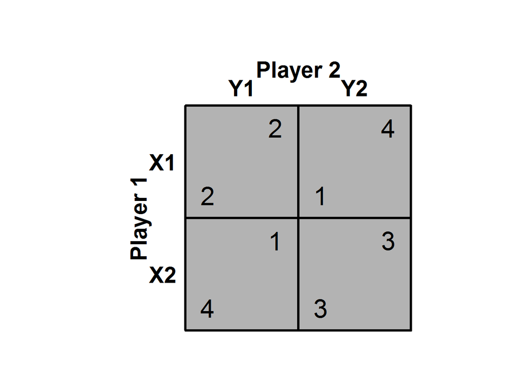

```r
gt_bimatrix(PD, nash = FALSE, arrow1 = FALSE,  tscale = .75)
```

And make it nicer like this:

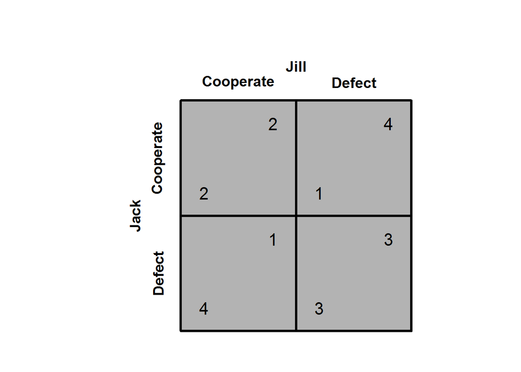

```r
gt_bimatrix(PD, nash = FALSE, arrow1 = FALSE, P1 = "Jack", P2 = "Jill",  labels1=c("Cooperate","Defect"), srt1=90, tscale = .5)
```

You can also add in best response arrows that show the incentives to change strategies; like this:

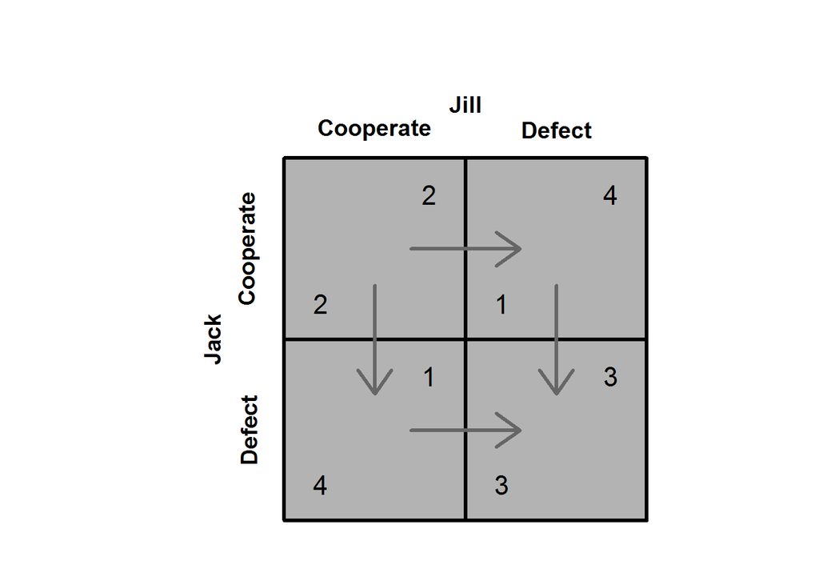

```r
gt_bimatrix(PD, nash = FALSE, arrow1 = TRUE, P1 = "Jack", P2 = "Jill",  labels1=c("Cooperate","Defect"), srt1=90, tscale = .5)
```

And add in a star to mark the Nash equilibria:

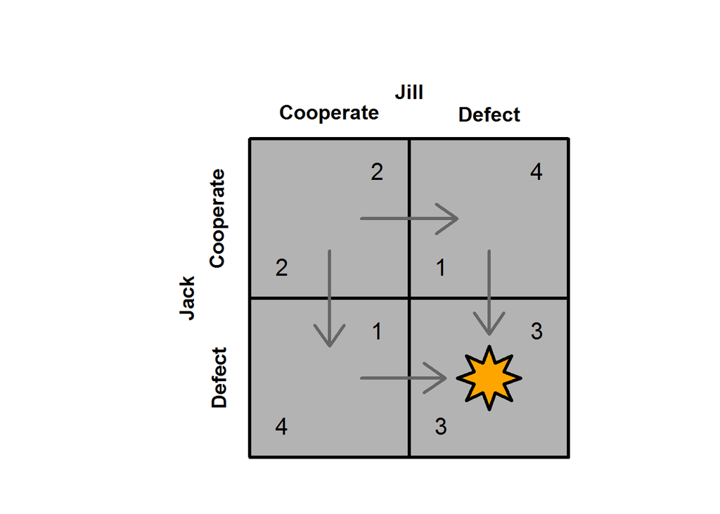

```r
gt_bimatrix(PD, P1 = "Jack", P2 = "Jill",  labels1=c("Cooperate","Defect"), srt1=90, tscale = .5)
```

These are useful especially for larger, more complex games:

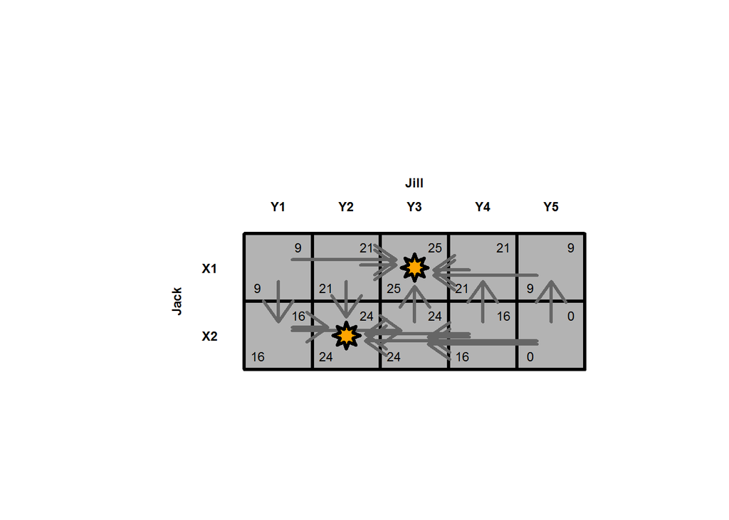

```r
Jack <- matrix(10*c(1:10) - (1:10)^2,2)
Jill <- matrix(10*c(1:10) - (1:10)^2,2)
gt_bimatrix(X=Jack, Y=Jill, P1 = "Jack", P2 = "Jill",  tscale = .5)
```

Of for quickly comparing families of games:

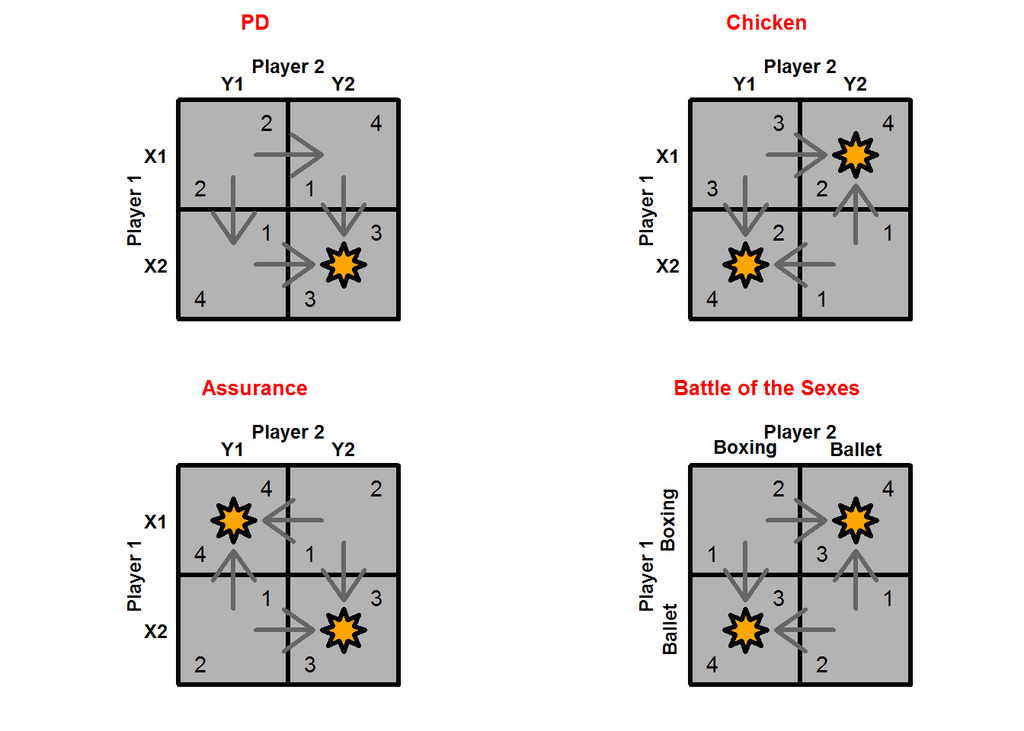

```r
par(mfrow=c(2,2))
gt_bimatrix(X = matrix(c(2,4,1,3),2,2), tscale = .4, main = "PD")
gt_bimatrix(X = matrix(c(3,4,2,1),2,2), tscale = .4, main = "Chicken")
gt_bimatrix(X = matrix(c(4,2,1,3),2,2), tscale = .4, main = "Assurance")
gt_bimatrix(X = matrix(c(1,4,3,2),2,2), Y = matrix(c(2,3,4,1),2,2),
            tscale = .4, labels1 = c("Boxing", "Ballet"), srt1=90,
            main = "Battle of the Sexes")
```